# ECON6027_5abcd

Dr. Liu

# Point Pattern Analysis

There are many planar point pattern (ppp) datasets that comes with the spatstat package. You are encouraged to use these datasets to practice the analytical methods in this chapter. One example is given below.

```r
library(spatstat, quietly=T)

# ppp
data(cells); class(cells)
```

```
## [1] "ppp"
```

```r
cells
```

```
## Planar point pattern: 42 points
## window: rectangle = [0, 1] x [0, 1] units
```

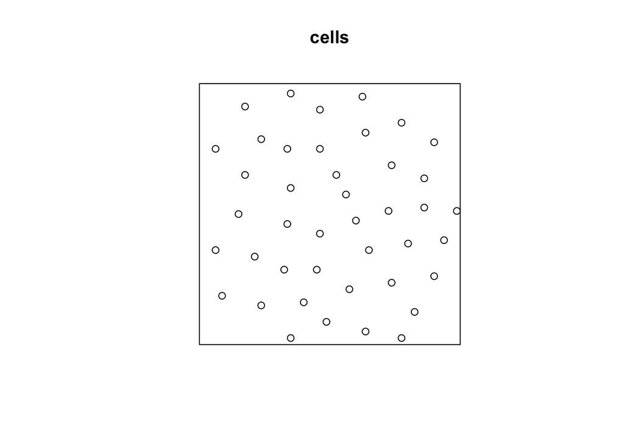

```r
plot(cells)
```

```r
rm(list = ls())
```

## 5a. Create a ppp object

For this chapter, we will use a generic spatial dataset that is loaded to R in the form of an sf object, to conduct the analysis. First we need to convert the usual sf point object to a ppp object. Start by loading the point observations. In this illustration, we will analyse the reported incidents of breaches of peace in the New Haven area.

```r
library(sf)
(breach = st_read("breach.shp")) # point data
```

```
## Simple feature collection with 180 features and 1 field
## Geometry type: POINT
## Dimension:     XY
## Bounding box:  xmin: 536895.7 ymin: 163291 xmax: 569227.2 ymax: 186172.3
## Projected CRS: +proj=lcc +lat_0=40.8333333333333 +lon_0=-72.75 +lat_1=41.8666666666667 +lat_2=41.2 +x_0=182880.365760732 +y_0=0 +ellps=clrk66 +nadgrids=@conus,@alaska,@ntv2_0.gsb,@ntv1_can.dat +units=us-ft +no_defs
```

```
## Simple feature collection with 180 features and 1 field
## Geometry type: POINT
## Dimension:     XY
## Bounding box:  xmin: 536895.7 ymin: 163291 xmax: 569227.2 ymax: 186172.3
## Projected CRS: +proj=lcc +lat_0=40.8333333333333 +lon_0=-72.75 +lat_1=41.8666666666667 +lat_2=41.2 +x_0=182880.365760732 +y_0=0 +ellps=clrk66 +nadgrids=@conus,@alaska,@ntv2_0.gsb,@ntv1_can.dat +units=us-ft +no_defs
## First 10 features:
##    FID                  geometry
## 1    0 POINT (551419.5 181266.3)
## 2    1 POINT (556319.5 177580.7)
## 3    2 POINT (551423.1 172304.5)
## 4    3 POINT (550261.9 182613.2)
## 5    4 POINT (555168.5 172163.4)
## 6    5 POINT (549133.6 169623.6)
## 7    6 POINT (548572.1 167430.2)
## 8    7 POINT (558373.1 173223.7)
## 9    8   POINT (539348 182779.2)
## 10   9 POINT (549729.3 177376.3)
```

```r
(breach = st_transform(breach, crs=2234))
```

```
## Simple feature collection with 180 features and 1 field
## Geometry type: POINT
## Dimension:     XY
## Bounding box:  xmin: 936897.4 ymin: 663293.5 xmax: 969228 ymax: 686175.2
## Projected CRS: NAD83 / Connecticut (ftUS)
## First 10 features:
##    FID                  geometry
## 1    0 POINT (951420.8 681269.1)
## 2    1 POINT (956320.7 677583.5)
## 3    2 POINT (951424.4 672307.2)
## 4    3 POINT (950263.3 682616.1)
## 5    4 POINT (955169.7 672166.1)
## 6    5   POINT (949135 669626.2)
## 7    6 POINT (948573.5 667432.9)
## 8    7 POINT (958374.3 673226.4)
## 9    8 POINT (939349.6 682782.1)
## 10   9   POINT (949730.7 677379)
```

```r
(breach = breach[ ,-1]) # remove FID column
```

```
## Simple feature collection with 180 features and 0 fields
## Geometry type: POINT
## Dimension:     XY
## Bounding box:  xmin: 936897.4 ymin: 663293.5 xmax: 969228 ymax: 686175.2
## Projected CRS: NAD83 / Connecticut (ftUS)
## First 10 features:
##                     geometry
## 1  POINT (951420.8 681269.1)
## 2  POINT (956320.7 677583.5)
## 3  POINT (951424.4 672307.2)
## 4  POINT (950263.3 682616.1)
## 5  POINT (955169.7 672166.1)
## 6    POINT (949135 669626.2)
## 7  POINT (948573.5 667432.9)
## 8  POINT (958374.3 673226.4)
## 9  POINT (939349.6 682782.1)
## 10   POINT (949730.7 677379)
```

```r
st_crs(breach)$proj # breach is projected, good to go
```

```
## [1] "lcc"
```

The FID is an object ID created automatically by the shapefile. However, when conducting point pattern analysis spatstat will identify the FID as an attribute (not an ID number). This is distorting to the analysis. So we have removed the FID before proceeding.

In the chunk below, we load the New Haven block polygon.

```r
blocks = st_read("blocks.shp") # New Haven polygon
```

```
## Simple feature collection with 129 features and 28 fields
## Geometry type: POLYGON
## Dimension:     XY
## Bounding box:  xmin: 531731.9 ymin: 147854 xmax: 569625.3 ymax: 188464.6
## Projected CRS: +proj=lcc +lat_0=40.8333333333333 +lon_0=-72.75 +lat_1=41.8666666666667 +lat_2=41.2 +x_0=182880.365760732 +y_0=0 +ellps=clrk66 +nadgrids=@conus,@alaska,@ntv2_0.gsb,@ntv1_can.dat +units=us-ft +no_defs
```

```r
blocks = st_transform(blocks, crs=2234)
table(st_is_valid(blocks)) # all valid
```

```
##
## TRUE
##  129
```

```r
isTRUE(all.equal(st_crs(breach), st_crs(blocks))) # CRS is projected and same as points
```

```
## [1] TRUE
```

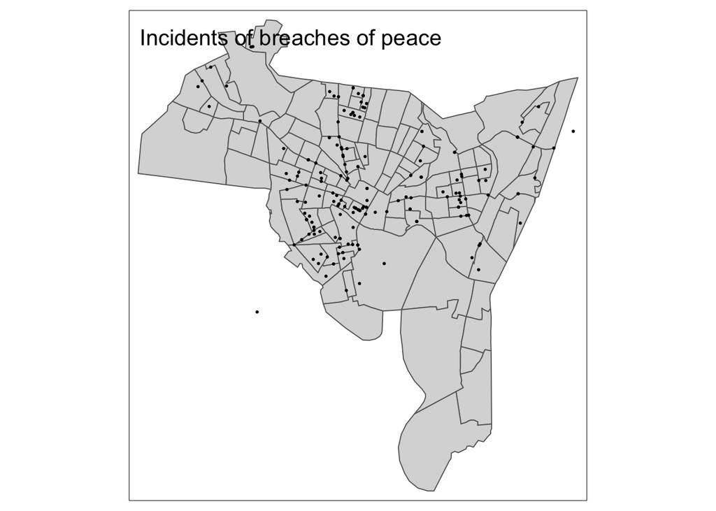

```r
library(tmap)
tm_shape(blocks) + tm_polygons() + tm_shape(breach) + tm_dots() +
  tm_layout(title = "Incidents of breaches of peace") +
  tmap_options(check.and.fix = TRUE)
```

Create the ppp object as follows.

```r
(breach.ppp = as.ppp(breach))
```

```
## Planar point pattern: 180 points
## window: rectangle = [936897.4, 969228] x [663293.5, 686175.2] units
```

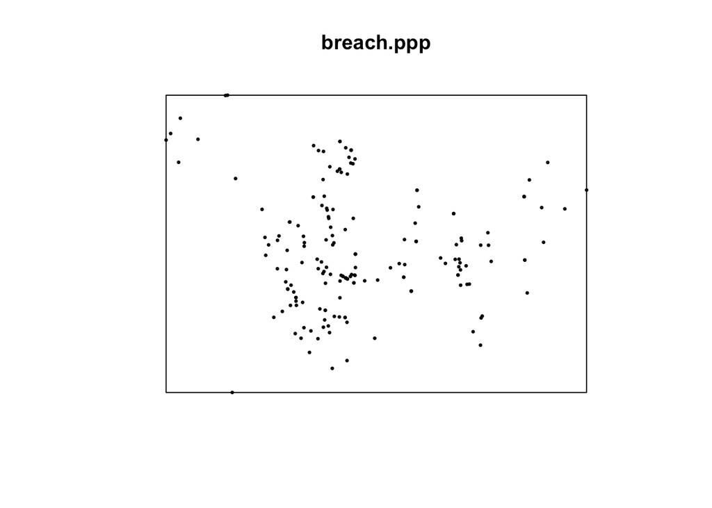

```r
plot(breach.ppp, pch=20, size=0.5)
```

```r
st_bbox(breach)
```

```
##     xmin     ymin     xmax     ymax
## 936897.4 663293.5 969228.0 686175.2
```

Add the boundary of New Haven as the window to the points data.

```r
nh = st_union(blocks) # Newhaven outline
(nh.owin = as.owin(nh)); class(nh.owin)
```

```
## window: polygonal boundary
## enclosing rectangle: [931733.8, 969626.1] x [647856.3, 688467.5] units
```

```
## [1] "owin"
```

```r
Window(breach.ppp) = nh.owin # assign windo to ppp object
breach.ppp # only 178 points, 2 points are outside the window!
```

```
## Planar point pattern: 178 points
## window: polygonal boundary
## enclosing rectangle: [931733.8, 969626.1] x [647856.3, 688467.5] units
```

When dealing with point data, you need to see whether there are any duplicated entries. If found, you may apply a simple perturbation function to randomly perturb the locations to remove duplicates.

```r
table(duplicated(breach.ppp)) # many duplicated entries
```

```
##
## FALSE  TRUE
##   157    21
```

```r
(breach.ppp = rjitter(breach.ppp, retry=T)); table(duplicated(breach.ppp))
```

```
## Planar point pattern: 178 points
## window: polygonal boundary
## enclosing rectangle: [931733.8, 969626.1] x [647856.3, 688467.5] units
```

```
##
## FALSE
##   178
```

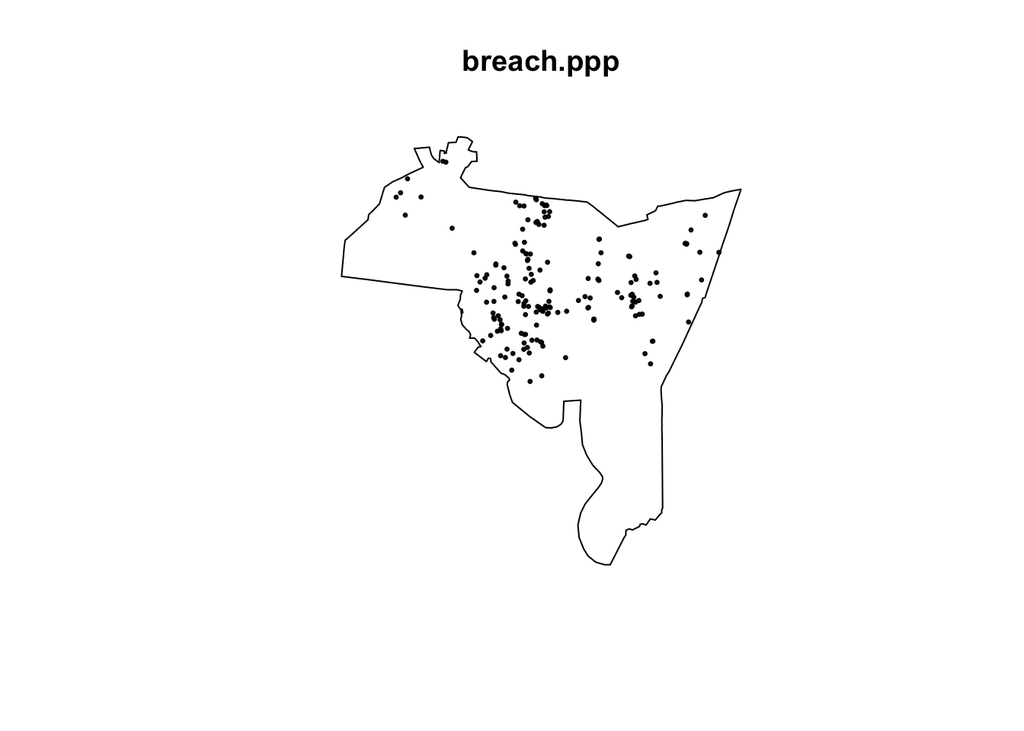

```r
plot(breach.ppp, pch=20, size=0.5)
```

## 5b. QC analysis

Prepare the quadrats and view

```r
(qc = quadratcount(breach.ppp, nx=10, ny=10))
```

```
## tile
##  Tile row 1, col 2  Tile row 1, col 3  Tile row 1, col 4  Tile row 2, col 1  Tile row 2, col 2
##                  1                  2                  0                  0                  4
##  Tile row 2, col 3  Tile row 2, col 4  Tile row 2, col 5  Tile row 2, col 6  Tile row 2, col 7
##                  0                  0                  9                  8                  0
##  Tile row 2, col 8  Tile row 2, col 9 Tile row 2, col 10  Tile row 3, col 1  Tile row 3, col 2
##                  0                  0                  1                  0                  0
##  Tile row 3, col 3  Tile row 3, col 4  Tile row 3, col 5  Tile row 3, col 6  Tile row 3, col 7
##                  1                  3                 11                  2                  4
##  Tile row 3, col 8  Tile row 3, col 9 Tile row 3, col 10  Tile row 4, col 1  Tile row 4, col 2
##                  2                  6                  1                  0                  0
##  Tile row 4, col 3  Tile row 4, col 4  Tile row 4, col 5  Tile row 4, col 6  Tile row 4, col 7
##                  0                  8                 21                  8                  9
##  Tile row 4, col 8  Tile row 4, col 9 Tile row 4, col 10  Tile row 5, col 3  Tile row 5, col 4
##                 16                  2                  1                  0                 10
##  Tile row 5, col 5  Tile row 5, col 6  Tile row 5, col 7  Tile row 5, col 8  Tile row 5, col 9
##                 18                 10                  3                  5                  1
##  Tile row 6, col 4  Tile row 6, col 5  Tile row 6, col 6  Tile row 6, col 7  Tile row 6, col 8
##                  1                  6                  2                  0                  2
##  Tile row 6, col 9  Tile row 7, col 5  Tile row 7, col 6  Tile row 7, col 7  Tile row 7, col 8
##                  0                  0                  0                  0                  0
##  Tile row 7, col 9  Tile row 8, col 7  Tile row 8, col 8  Tile row 8, col 9  Tile row 9, col 6
##                  0                  0                  0                  0                  0
##  Tile row 9, col 7  Tile row 9, col 8  Tile row 9, col 9 Tile row 10, col 6 Tile row 10, col 7
##                  0                  0                  0                  0                  0
## Tile row 10, col 8
##                  0
```

```r
class(qc)
```

```
## [1] "quadratcount" "table"
```

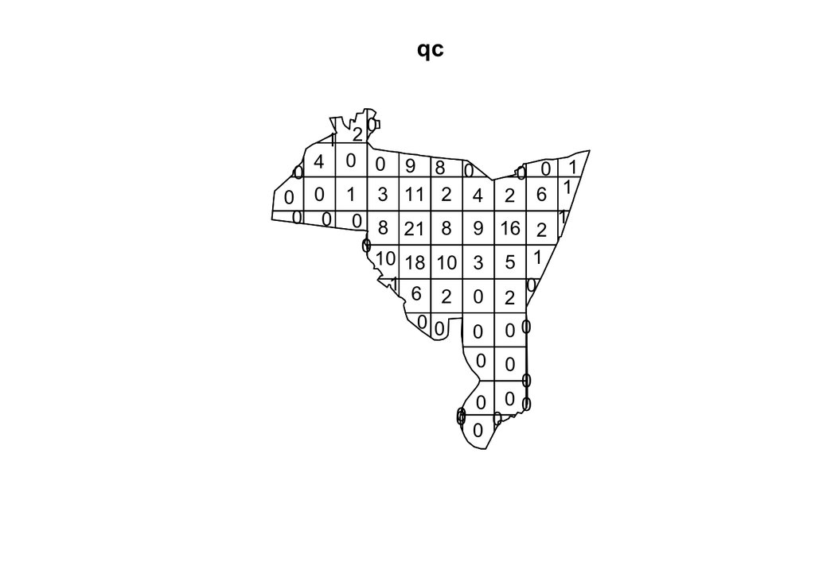

```r
plot(qc)
```

Chi2 (goodness of fit) test

```r
(quad.test = quadrat.test(breach.ppp, nx=10, ny=10))
```

```
##
##  Chi-squared test of CSR using quadrat counts
##
## data:  breach.ppp
## X2 = 282.02, df = 60, p-value < 2.2e-16
## alternative hypothesis: two.sided
##
## Quadrats: 61 tiles (irregular windows)
```

Test outcome: Reject the null of qc~Po(lambda) at 5% level.

We can run some computations to confirm the test results above…

1. Estimate the null parameter (lambda_0)

```r
# View(quad.test) # inspect the quad.test list object.
quad.test$observed # gives the observed number of points in each quadrat
```

```
##  [1]  1  2  0  0  4  0  0  9  8  0  0  0  1  0  0  1  3 11  2  4  2  6  1  0  0  0  8 21  8  9 16
## [32]  2  1  0 10 18 10  3  5  1  1  6  2  0  2  0  0  0  0  0  0  0  0  0  0  0  0  0  0  0  0
```

```r
quad.test$parameter # gives the number of df (i.e. n=df+1)
```

```
## df
## 60
```

```r
(n = quad.test$parameter+1)
```

```
## df
## 61
```

```r
(lambda = mean(quad.test$observed)) # Average number of points per quadrat
```

```
## [1] 2.918033
```

Null distribution:If X~Po(lambda)

Null vs. observed distribution of counts (optional)

```r
(observed = table(quad.test$observed))
```

```
##
##  0  1  2  3  4  5  6  8  9 10 11 16 18 21
## 30  7  6  2  2  1  2  3  2  2  1  1  1  1
```

```r
(max.num = max(quad.test$observed)) # maximum number of observations in a single quadrat
```

```
## [1] 21
```

```r
(max.freq = max(observed)) # maximum frequency
```

```
## [1] 30
```

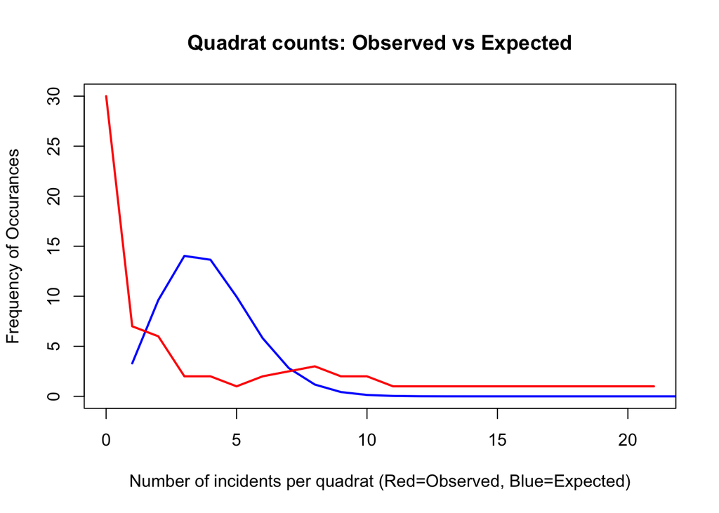

```r
plot(c(0,max.num),c(0,max.freq), type="n",
     xlab="Number of incidents per quadrat (Red=Observed, Blue=Expected)",
     ylab="Frequency of Occurances", main="Quadrat counts: Observed vs Expected")
points(dpois(0:max.num, lambda=lambda)*n, type="l", col="Blue", lwd=2)
points(observed, col="Red", type="l", lwd=2)
```

Clearly, when comparing the observed and expected counts, we can say that the point pattern does not follow a HPP as confirmed by the Chi2 test.

## Kernel density estimation

KDE is highly sensitive to the choice of the bandwidth. Here we make two estimates for sigma=500 and sigma=1000 respectively.

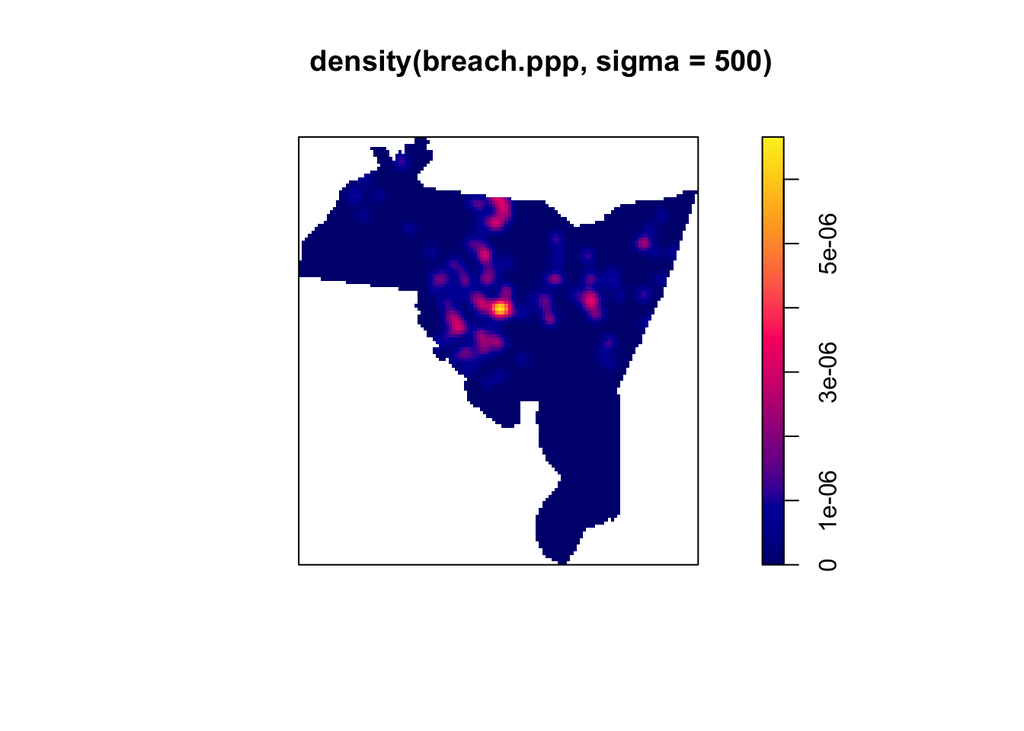

```r
plot(density(breach.ppp, sigma=500))
```

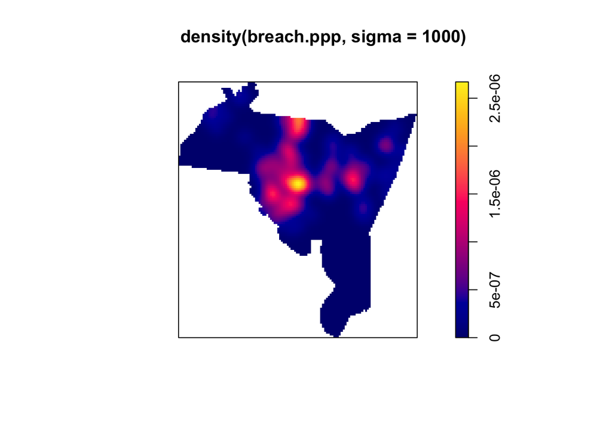

```r
plot(density(breach.ppp, sigma=1000))
```

Run ?density.ppp for more information.

Bandwidth selection can also be automated by applying a pre-selected optimal bandwidth selection method. The following chunk uses the famous diggle method. The bandwidth is chosen to minimise the mean-square error criterion defined by Diggle (1985). Alternative methods include: bw.ppl, bw.scott, bw.CvL, bw.frac.

```r
(breach.bw = bw.diggle(breach.ppp))
```

```
##    sigma
## 342.9593
```

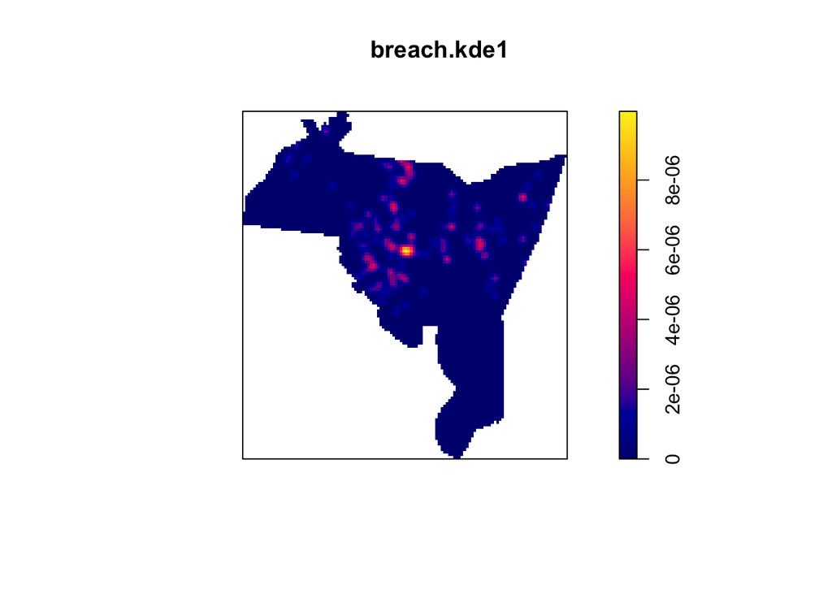

```r
breach.kde1 = density(breach.ppp, sigma=bw.diggle(breach.ppp))
plot(breach.kde1)
```

## 5d. Nearest neighbour distance analysis

The standard error of the CE index is verified as below (slide 8)

```r
sqrt((4-pi)/(4*pi))
```

```
## [1] 0.2613616
```

The CE index for the breaches of peace data is computed below with the test following thereafter. See: https://www.rdocumentation.org/packages/spatstat/versions/1.64-1/topics/clarkevans

```r
clarkevans(breach.ppp, correction="none")
```

```
## [1] 0.5369067
```

```r
clarkevans.test(breach.ppp, correction="none", alternative="less")
```

```
##
##  Clark-Evans test
##  No edge correction
##  Z-test
##
## data:  breach.ppp
## R = 0.53691, p-value < 2.2e-16
## alternative hypothesis: clustered (R < 1)
```

Here we have conducted a one tailed test: Is the R index significantly smaller than 1 (in other words, do we have reasons to believe clustering in “breach”)?

Based on the test there seem to be significant clustering of incidences related to breaches of peace! Note that the spceific alternative considered in this test is R<1 which means there is clustering. Other alternatives can also be considered. Run ?clarkevans.test

By right the above chunk is all that is needed to conduct a CE test for CSR. However, if you wish to dig deeped into the components of this test and verify how the numbers are calculated, you can use the following (optional calculations).

```r
breach.nnd = nndist(breach.ppp, k=1) # nearest neighbour distances.
summary(breach.nnd)
```

```
##    Min. 1st Qu.  Median    Mean 3rd Qu.    Max.
##   10.64  115.77  351.29  502.90  670.61 3114.23
```

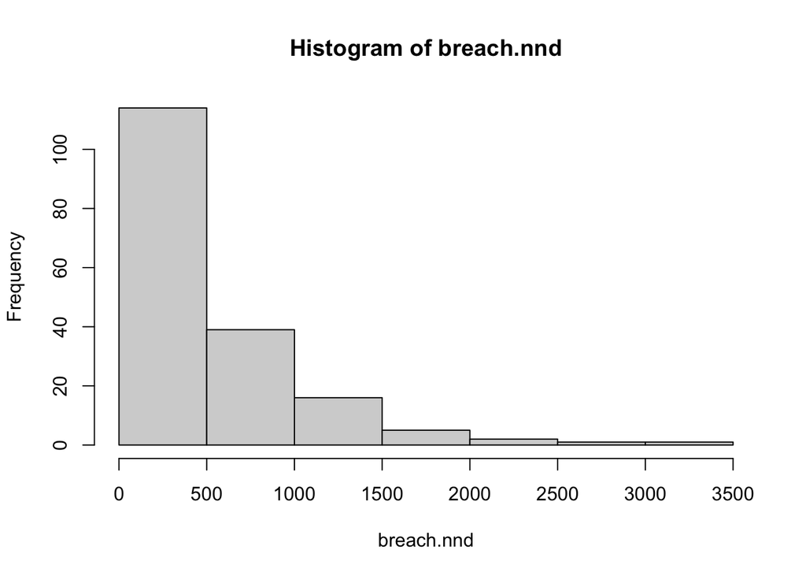

```r
hist(breach.nnd)
```

```r
class(breach.nnd)
```

```
## [1] "numeric"
```

```r
breach.nnd = as.matrix(breach.nnd) # convert breach.nnd to a matrix.

(r.bar = sum(breach.nnd)/nrow(breach.nnd)) # Observed average r
```

```
## [1] 502.9027
```

```r
(Er = 0.5*sqrt(area.owin(nh.owin)/nrow(breach.nnd))) # expected r
```

```
## [1] 936.6668
```

```r
(CE.index = r.bar/Er)
```

```
## [1] 0.5369067
```

```r
(Zstat = ((r.bar-Er)/ 0.26136)*sqrt(nrow(breach.nnd)^2/area.owin(nh.owin))) # test statistic
```

```
## [1] -11.81978
```

The p-value given in the test is computed based on this Zstat!

## K-function analysis

```
## Generating 99 simulations of CSR  ...
## 1, 2, 3, 4, 5, 6, 7, 8, 9, 10, 11, 12, 13, 14, 15, 16, 17, 18, 19, 20, 21, 22, 23, 24,
## 25, 26, 27, 28, 29, 30, 31, 32, 33, 34, 35, 36, 37, 38, 39, 40, 41, 42, 43, 44, 45, 46, 47, 48,
## 49, 50, 51, 52, 53, 54, 55, 56, 57, 58, 59, 60, 61, 62, 63, 64, 65, 66, 67, 68, 69, 70, 71, 72,
## 73, 74, 75, 76, 77, 78, 79, 80, 81, 82, 83, 84, 85, 86, 87, 88, 89, 90, 91, 92, 93, 94, 95, 96,
## 97, 98,
## 99.
##
## Done.
```

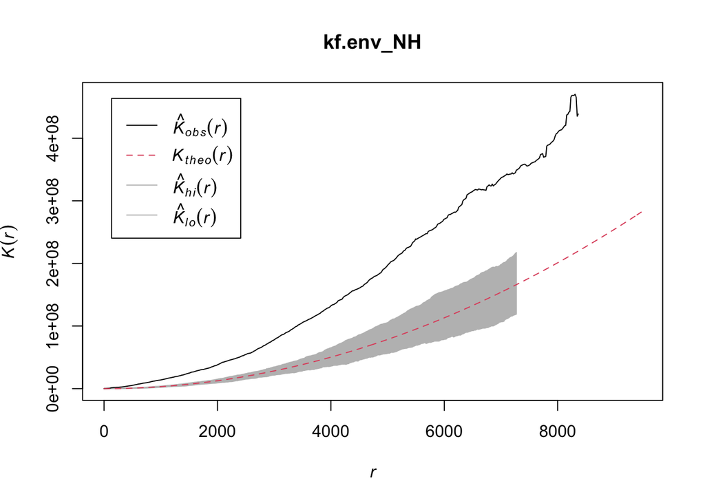

```r
kf.env_NH = envelope(breach.ppp, Kest, correction="border"); plot(kf.env_NH)
```

```
## Generating 99 simulations of CSR  ...
## 1, 2, 3, 4, 5, 6, 7, 8, 9, 10, 11, 12, 13, 14, 15, 16, 17, 18, 19, 20, 21, 22, 23, 24,
## 25, 26, 27, 28, 29, 30, 31, 32, 33, 34, 35, 36, 37, 38, 39, 40, 41, 42, 43, 44, 45, 46, 47, 48,
## 49, 50, 51, 52, 53, 54, 55, 56, 57, 58, 59, 60, 61, 62, 63, 64, 65, 66, 67, 68, 69, 70, 71, 72,
## 73, 74, 75, 76, 77, 78, 79, 80, 81, 82, 83, 84, 85, 86, 87, 88, 89, 90, 91, 92, 93, 94, 95, 96,
## 97, 98,
## 99.
##
## Done.
```

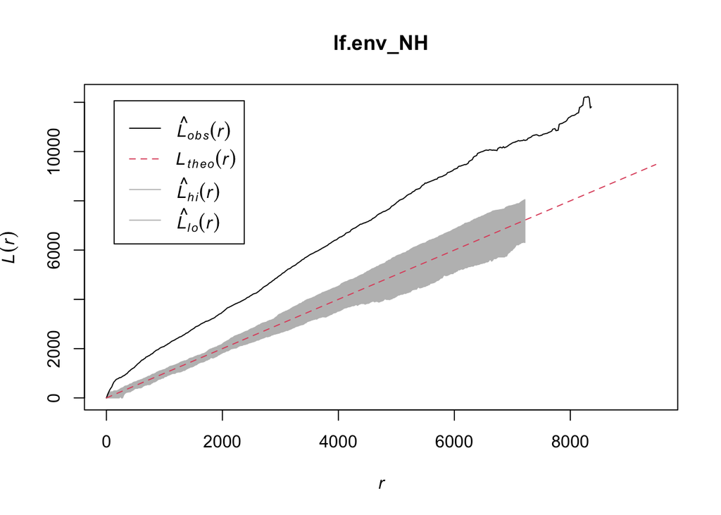

```r
lf.env_NH = envelope(breach.ppp, Lest, correction="border"); plot(lf.env_NH)
```

```
## Generating 99 simulations of CSR  ...
## 1, 2, 3, 4, 5, 6, 7, 8, 9, 10, 11, 12, 13, 14, 15, 16, 17, 18, 19, 20, 21, 22, 23, 24,
## 25, 26, 27, 28, 29, 30, 31, 32, 33, 34, 35, 36, 37, 38, 39, 40, 41, 42, 43, 44, 45, 46, 47, 48,
## 49, 50, 51, 52, 53, 54, 55, 56, 57, 58, 59, 60, 61, 62, 63, 64, 65, 66, 67, 68, 69, 70, 71, 72,
## 73, 74, 75, 76, 77, 78, 79, 80, 81, 82, 83, 84, 85, 86, 87, 88, 89, 90, 91, 92, 93, 94, 95, 96,
## 97, 98,
## 99.
##
## Done.
```

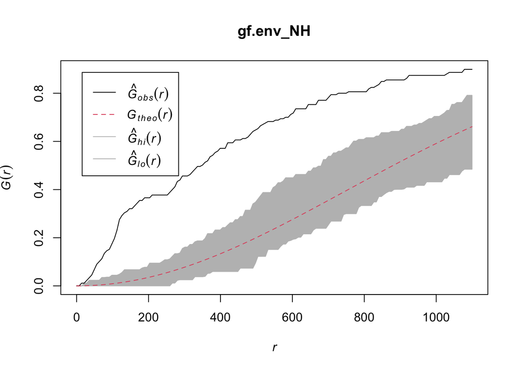

```r
gf.env_NH = envelope(breach.ppp, Gest, correction="best"); plot(gf.env_NH)
```

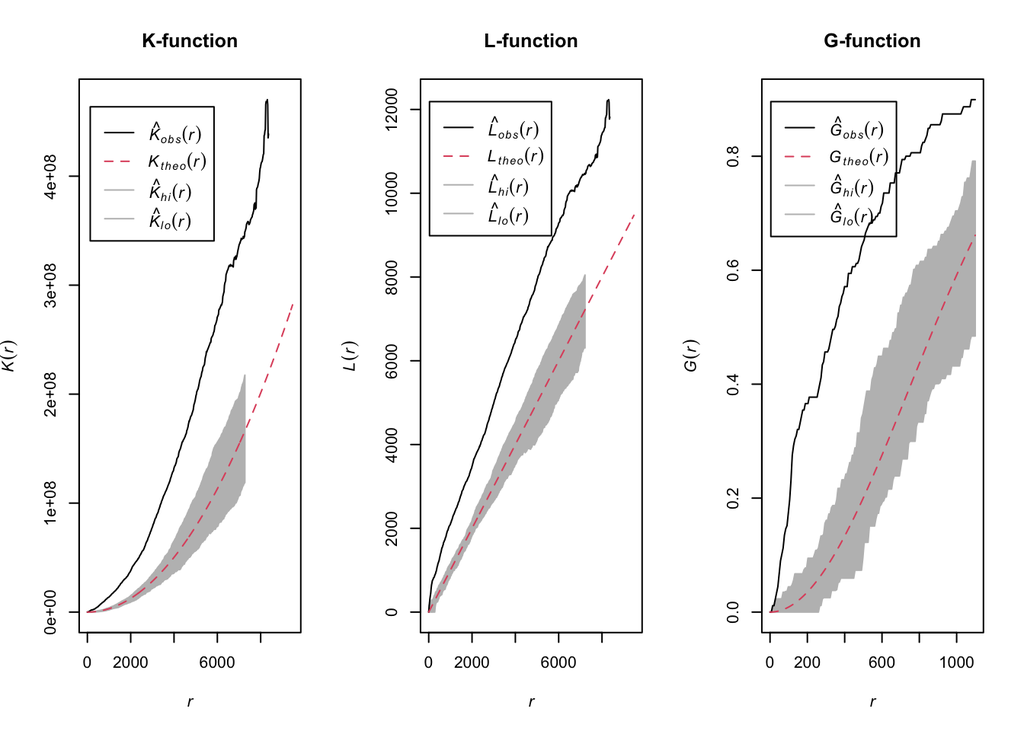

```r
par(mfrow=c(1,3))
plot(kf.env_NH, main="K-function")
plot(lf.env_NH, main="L-function")
plot(gf.env_NH, main="G-function")
```

```r
par(mfrow=c(1,1))
```